# Peer-Graded Assignment: R Markdown & Plotly

10/16/2017

## Stage 1: Exploratory Data Analysis

## Our Question

"Was there any significant relationship between class, age, and/or sex and the mortality of those who were aboard on the Titanic?"

## Data Summary (Out of the Box)

```
## 'data.frame':    32 obs. of  5 variables:
##  $ Class   : Factor w/ 4 levels "1st","2nd","3rd",..: 1 2 3 4 1 2 3 4 1 2 ...
##  $ Sex     : Factor w/ 2 levels "Male","Female": 1 1 1 1 2 2 2 2 1 1 ...
##  $ Age     : Factor w/ 2 levels "Child","Adult": 1 1 1 1 1 1 1 1 2 2 ...
##  $ Survived: Factor w/ 2 levels "No","Yes": 1 1 1 1 1 1 1 1 1 1 ...
##  $ Freq    : num  0 0 35 0 0 0 17 0 118 154 ...
```

Note that this data is made up of 4 factor-based predictor variables (Class, Sex, Age, Survived), and one numerical outcome variable (Freq).

As such, we'll probably have to run some regression-based statistical tests to answer our question.

## Tidying Up the Data

Since there were varying numbers of people in each Class aboard the Titanic, we should probably be looking at the proportions of people who died , rather than absolute numbers, so let's clean up the data and make an outcome variable called "Percent_Dead" instead.

Below shows the top 5 groups with the highest mortality:

| Class | Sex | Age | Num_Passengers | Deaths | Percent_Dead |
| --- | --- | --- | --- | --- | --- |
| 2nd | Male | Adult | 168 | 154 | 91.67 |
| 3rd | Male | Adult | 462 | 387 | 83.77 |
| Crew | Male | Adult | 862 | 670 | 77.73 |
| 3rd | Male | Child | 48 | 35 | 72.92 |
| 1st | Male | Adult | 175 | 118 | 67.43 |

## Visual Assessment of Trends

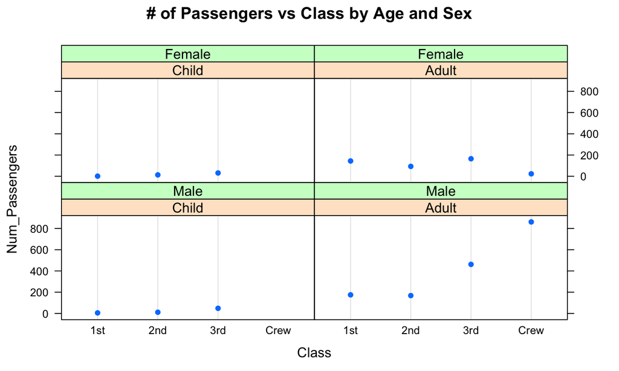

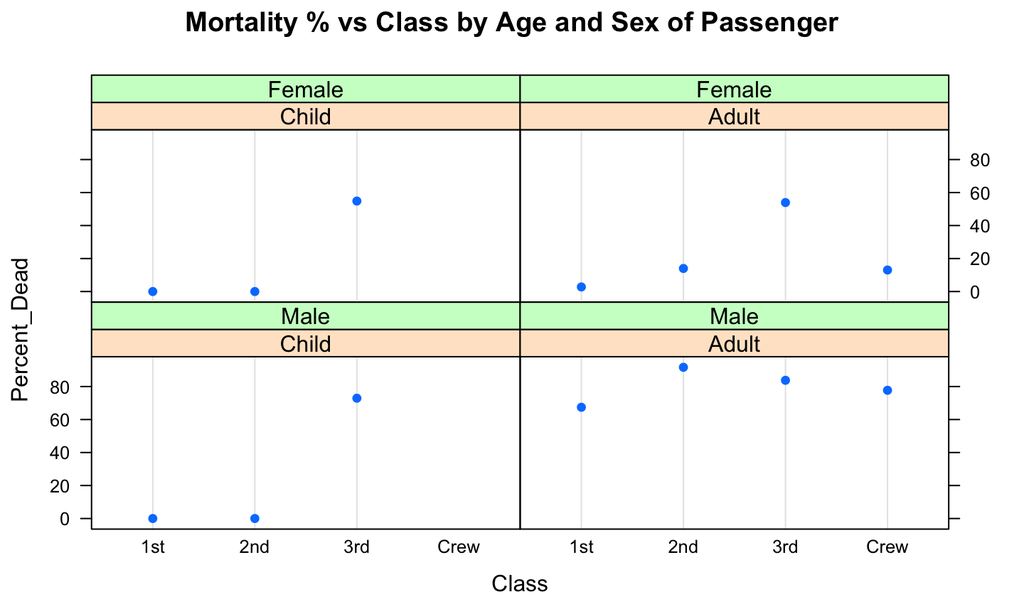

One thing that stands out from the data is that overall there were far more adults than children on the Titanic, and that the mortality rates for adult men were high in all classes.

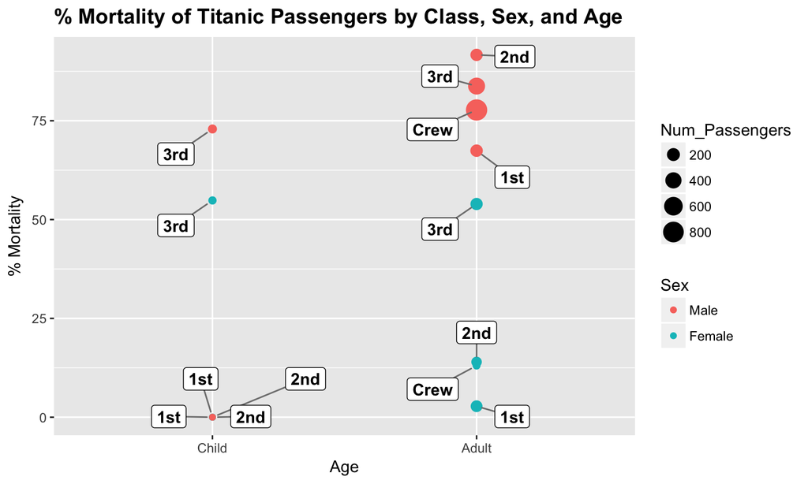

We can also see that in general, 3rd-class passengers suffered mortality rates of over 50%, regardless of age and sex.

## Graph published with Plotly

[interactive chart not shown]